# examples_0429

Solve the equation below.
$$63=(x+3)\cdot
9$$

Rewrite the given equation.
$$63=(x+3)\cdot 9$$
Divide both sides of the equation by 9.

$$7=x+3$$

Subtract 3 from both sides of the equation.

$$4=x$$

Switch sides (which is allowed because equality is commutative).

$$x=4$$

You can check your possible answer by substituting 4 for $x$ in the original equation.

$$63\stackrel{?}{=}((4)+3)\cdot
9$$

$$63 \stackrel{?}{=} 7\cdot 9$$

$$63 \stackrel{\checkmark}{=}
63$$

So, indeed we see that $x=4$ is a solution to the equation.

Solve the equation below.
$$34=8
x-6$$

Rewrite the given equation.
$$34=8
x-6$$
Add 6 to both sides of the equation.

$$40=8 x$$

Divide both sides of the equation by 8.

$$5=x$$

Switch sides (which is allowed because equality is commutative).

$$x=5$$

You can check your possible answer by substituting 5 for $x$ in the original equation.

$$34\stackrel{?}{=}8 (5)-6$$

$$34 \stackrel{?}{=} 40-6$$

$$34 \stackrel{\checkmark}{=}
34$$

So, indeed we see that $x=5$ is a solution to the equation.

Solve the equation below.
$$33=4
x+5$$

Rewrite the given equation.
$$33=4
x+5$$
Subtract 5 from both sides of the equation.

$$28=4 x$$

Divide both sides of the equation by 4.

$$7=x$$

Switch sides (which is allowed because equality is commutative).

$$x=7$$

You can check your possible answer by substituting 7 for $x$ in the original equation.

$$33\stackrel{?}{=}4 (7)+5$$

$$33 \stackrel{?}{=} 28+5$$

$$33 \stackrel{\checkmark}{=}
33$$

So, indeed we see that $x=7$ is a solution to the equation.

Solve the equation below.
$$60=(x+7)\cdot
6$$

Rewrite the given equation.
$$60=(x+7)\cdot 6$$
Divide both sides of the equation by 6.

$$10=x+7$$

Subtract 7 from both sides of the equation.

$$3=x$$

Switch sides (which is allowed because equality is commutative).

$$x=3$$

You can check your possible answer by substituting 3 for $x$ in the original equation.

$$60\stackrel{?}{=}((3)+7)\cdot
6$$

$$60 \stackrel{?}{=} 10\cdot
6$$

$$60 \stackrel{\checkmark}{=}
60$$

So, indeed we see that $x=3$ is a solution to the equation.

Solve the equation below.
$$3=\frac{x-3}{2}$$

Rewrite the given equation.
$$3=\frac{x-3}{2}$$
Multiply both sides of the equation by 2.

$$6=x-3$$

Add 3 to both sides of the equation.

$$9=x$$

Switch sides (which is allowed because equality is commutative).

$$x=9$$

You can check your possible answer by substituting 9 for $x$ in the original equation.

$$3\stackrel{?}{=}\frac{(9)-3}{2}$$

$$3 \stackrel{?}{=}
\frac{6}{2}$$

$$3 \stackrel{\checkmark}{=}
3$$

So, indeed we see that $x=9$ is a solution to the equation.

On the curve $y=\sqrt{x}$ exists the point $(100,10)$ because $10=\sqrt{100}$.

We can transform the square-root function horizontally and vertically to create a new curve defined by the equation below:

$$y=2\cdot
\sqrt{\frac{x-8}{5}}-4$$

Find this curve's corresponding point by finding the value of $x$ that makes the radicand equal to 100, and then find the $y$ value by evaluating the right side of the equation. Express that point using parentheses, a comma separator, and no spaces. For example, type `(18,-5)` for the point $(18,-5)$.

Set the radicand (the argument of the square-root function) equal to 100.

$$\frac{x-8}{5}=100$$

Solve the two-step (or maybe three-step) linear equation.

$$x=508$$

Plug $x=508$ into equation.

$$y=2\cdot
\sqrt{\frac{(508)-8}{5}}-4$$

Simplify the radicand.

$$y=2\cdot \sqrt{100}-4$$

Evaluate the radical.

$$y=2\cdot 10-4$$

Evaluate the right side using PEMDAS.

$$y=16$$

So, the corresponding point on the transformed curve is `(508,16)`.

On the curve $y=\sqrt{x}$ exists the point $(16,4)$ because $4=\sqrt{16}$.

We can transform the square-root function horizontally and vertically to create a new curve defined by the equation below:

$$y=5\cdot\left(\sqrt{3
x+4}-10\right)$$

Find this curve's corresponding point by finding the value of $x$ that makes the radicand equal to 16, and then find the $y$ value by evaluating the right side of the equation. Express that point using parentheses, a comma separator, and no spaces. For example, type `(18,-5)` for the point $(18,-5)$.

Set the radicand (the argument of the square-root function) equal to 16.

$$3 x+4=16$$

Solve the two-step (or maybe three-step) linear equation.

$$x=4$$

Plug $x=4$ into equation.

$$y=5\cdot\left(\sqrt{3
(4)+4}-10\right)$$

Simplify the radicand.

$$y=5\cdot\left(\sqrt{16}-10\right)$$

Evaluate the radical.

$$y=5\cdot\left(4-10\right)$$

Evaluate the right side using PEMDAS.

$$y=-30$$

So, the corresponding point on the transformed curve is `(4,-30)`.

On the curve $y=\sqrt{x}$ exists the point $(36,6)$ because $6=\sqrt{36}$.

We can transform the square-root function horizontally and vertically to create a new curve defined by the equation below:

$$y=\frac{\sqrt{\frac{x}{6}+5}}{3}-4$$

Find this curve's corresponding point by finding the value of $x$ that makes the radicand equal to 36, and then find the $y$ value by evaluating the right side of the equation. Express that point using parentheses, a comma separator, and no spaces. For example, type `(18,-5)` for the point $(18,-5)$.

Set the radicand (the argument of the square-root function) equal to 36.

$$\frac{x}{6}+5=36$$

Solve the two-step (or maybe three-step) linear equation.

$$x=186$$

Plug $x=186$ into equation.

$$y=\frac{\sqrt{\frac{(186)}{6}+5}}{3}-4$$

Simplify the radicand.

$$y=\frac{\sqrt{36}}{3}-4$$

Evaluate the radical.

$$y=\frac{6}{3}-4$$

Evaluate the right side using PEMDAS.

$$y=-2$$

So, the corresponding point on the transformed curve is `(186,-2)`.

On the curve $y=\sqrt{x}$ exists the point $(49,7)$ because $7=\sqrt{49}$.

We can transform the square-root function horizontally and vertically to create a new curve defined by the equation below:

$$y=-5\cdot\left(\sqrt{-2
x+7}-8\right)$$

Find this curve's corresponding point by finding the value of $x$ that makes the radicand equal to 49, and then find the $y$ value by evaluating the right side of the equation. Express that point using parentheses, a comma separator, and no spaces. For example, type `(18,-5)` for the point $(18,-5)$.

Set the radicand (the argument of the square-root function) equal to 49.

$$-2 x+7=49$$

Solve the two-step (or maybe three-step) linear equation.

$$x=-21$$

Plug $x=-21$ into equation.

$$y=-5\cdot\left(\sqrt{-2
(-21)+7}-8\right)$$

Simplify the radicand.

$$y=-5\cdot\left(\sqrt{49}-8\right)$$

Evaluate the radical.

$$y=-5\cdot\left(7-8\right)$$

Evaluate the right side using PEMDAS.

$$y=5$$

So, the corresponding point on the transformed curve is `(-21,5)`.

On the curve $y=\sqrt{x}$ exists the point $(16,4)$ because $4=\sqrt{16}$.

We can transform the square-root function horizontally and vertically to create a new curve defined by the equation below:

$$y=\frac{\sqrt{-2 x-8}+5}{3}$$

Find this curve's corresponding point by finding the value of $x$ that makes the radicand equal to 16, and then find the $y$ value by evaluating the right side of the equation. Express that point using parentheses, a comma separator, and no spaces. For example, type `(18,-5)` for the point $(18,-5)$.

Set the radicand (the argument of the square-root function) equal to 16.

$$-2 x-8=16$$

Solve the two-step (or maybe three-step) linear equation.

$$x=-12$$

Plug $x=-12$ into equation.

$$y=\frac{\sqrt{-2
(-12)-8}+5}{3}$$

Simplify the radicand.

$$y=\frac{\sqrt{16}+5}{3}$$

Evaluate the radical.

$$y=\frac{4+5}{3}$$

Evaluate the right side using PEMDAS.

$$y=3$$

So, the corresponding point on the transformed curve is `(-12,3)`.

Simplify the radical:

$$\sqrt{28}$$

$2\sqrt{2}$$2\sqrt{3}$$2\sqrt{5}$$2\sqrt{7}$$2\sqrt{11}$$3\sqrt{2}$$3\sqrt{3}$$3\sqrt{5}$$3\sqrt{7}$$3\sqrt{11}$$5\sqrt{2}$$5\sqrt{3}$$5\sqrt{5}$$5\sqrt{7}$$5\sqrt{11}$$7\sqrt{2}$$7\sqrt{3}$$7\sqrt{5}$$7\sqrt{7}$$7\sqrt{11}$$11\sqrt{2}$$11\sqrt{3}$$11\sqrt{5}$$11\sqrt{7}$$11\sqrt{11}$

$$\sqrt{28}$$

Find the [prime factorization](https://en.wikipedia.org/wiki/Fundamental_theorem_of_arithmetic) of 28. You can do this with a [factor tree](https://www.khanacademy.org/math/pre-algebra/pre-algebra-factors-multiples/pre-algebra-prime-factorization-prealg/v/prime-factorization). You should find that $28=2^{2}\cdot7^{1}$.

$$\sqrt{2^{2}\cdot7^{1}}$$

[Simplify the square root](https://www.khanacademy.org/math/algebra/x2f8bb11595b61c86:rational-exponents-radicals/x2f8bb11595b61c86:simplifying-square-roots/v/simplifying-square-roots-1).

$$2 \sqrt{7}$$

Simplify the radical:

$$\sqrt{27}$$

$2\sqrt{2}$$2\sqrt{3}$$2\sqrt{5}$$2\sqrt{7}$$2\sqrt{11}$$3\sqrt{2}$$3\sqrt{3}$$3\sqrt{5}$$3\sqrt{7}$$3\sqrt{11}$$5\sqrt{2}$$5\sqrt{3}$$5\sqrt{5}$$5\sqrt{7}$$5\sqrt{11}$$7\sqrt{2}$$7\sqrt{3}$$7\sqrt{5}$$7\sqrt{7}$$7\sqrt{11}$$11\sqrt{2}$$11\sqrt{3}$$11\sqrt{5}$$11\sqrt{7}$$11\sqrt{11}$

$$\sqrt{27}$$

Find the [prime factorization](https://en.wikipedia.org/wiki/Fundamental_theorem_of_arithmetic) of 27. You can do this with a [factor tree](https://www.khanacademy.org/math/pre-algebra/pre-algebra-factors-multiples/pre-algebra-prime-factorization-prealg/v/prime-factorization). You should find that $27=3^{3}$.

$$\sqrt{3^{3}}$$

[Simplify the square root](https://www.khanacademy.org/math/algebra/x2f8bb11595b61c86:rational-exponents-radicals/x2f8bb11595b61c86:simplifying-square-roots/v/simplifying-square-roots-1).

$$3 \sqrt{3}$$

Simplify the radical:

$$\sqrt{18}$$

$2\sqrt{2}$$2\sqrt{3}$$2\sqrt{5}$$2\sqrt{7}$$2\sqrt{11}$$3\sqrt{2}$$3\sqrt{3}$$3\sqrt{5}$$3\sqrt{7}$$3\sqrt{11}$$5\sqrt{2}$$5\sqrt{3}$$5\sqrt{5}$$5\sqrt{7}$$5\sqrt{11}$$7\sqrt{2}$$7\sqrt{3}$$7\sqrt{5}$$7\sqrt{7}$$7\sqrt{11}$$11\sqrt{2}$$11\sqrt{3}$$11\sqrt{5}$$11\sqrt{7}$$11\sqrt{11}$

$$\sqrt{18}$$

Find the [prime factorization](https://en.wikipedia.org/wiki/Fundamental_theorem_of_arithmetic) of 18. You can do this with a [factor tree](https://www.khanacademy.org/math/pre-algebra/pre-algebra-factors-multiples/pre-algebra-prime-factorization-prealg/v/prime-factorization). You should find that $18=2^{1}\cdot3^{2}$.

$$\sqrt{2^{1}\cdot3^{2}}$$

[Simplify the square root](https://www.khanacademy.org/math/algebra/x2f8bb11595b61c86:rational-exponents-radicals/x2f8bb11595b61c86:simplifying-square-roots/v/simplifying-square-roots-1).

$$3 \sqrt{2}$$

Simplify the radical:

$$\sqrt{75}$$

$2\sqrt{2}$$2\sqrt{3}$$2\sqrt{5}$$2\sqrt{7}$$2\sqrt{11}$$3\sqrt{2}$$3\sqrt{3}$$3\sqrt{5}$$3\sqrt{7}$$3\sqrt{11}$$5\sqrt{2}$$5\sqrt{3}$$5\sqrt{5}$$5\sqrt{7}$$5\sqrt{11}$$7\sqrt{2}$$7\sqrt{3}$$7\sqrt{5}$$7\sqrt{7}$$7\sqrt{11}$$11\sqrt{2}$$11\sqrt{3}$$11\sqrt{5}$$11\sqrt{7}$$11\sqrt{11}$

$$\sqrt{75}$$

Find the [prime factorization](https://en.wikipedia.org/wiki/Fundamental_theorem_of_arithmetic) of 75. You can do this with a [factor tree](https://www.khanacademy.org/math/pre-algebra/pre-algebra-factors-multiples/pre-algebra-prime-factorization-prealg/v/prime-factorization). You should find that $75=3^{1}\cdot5^{2}$.

$$\sqrt{3^{1}\cdot5^{2}}$$

[Simplify the square root](https://www.khanacademy.org/math/algebra/x2f8bb11595b61c86:rational-exponents-radicals/x2f8bb11595b61c86:simplifying-square-roots/v/simplifying-square-roots-1).

$$5 \sqrt{3}$$

Simplify the radical:

$$\sqrt{28}$$

$2\sqrt{2}$$2\sqrt{3}$$2\sqrt{5}$$2\sqrt{7}$$2\sqrt{11}$$3\sqrt{2}$$3\sqrt{3}$$3\sqrt{5}$$3\sqrt{7}$$3\sqrt{11}$$5\sqrt{2}$$5\sqrt{3}$$5\sqrt{5}$$5\sqrt{7}$$5\sqrt{11}$$7\sqrt{2}$$7\sqrt{3}$$7\sqrt{5}$$7\sqrt{7}$$7\sqrt{11}$$11\sqrt{2}$$11\sqrt{3}$$11\sqrt{5}$$11\sqrt{7}$$11\sqrt{11}$

$$\sqrt{28}$$

Find the [prime factorization](https://en.wikipedia.org/wiki/Fundamental_theorem_of_arithmetic) of 28. You can do this with a [factor tree](https://www.khanacademy.org/math/pre-algebra/pre-algebra-factors-multiples/pre-algebra-prime-factorization-prealg/v/prime-factorization). You should find that $28=2^{2}\cdot7^{1}$.

$$\sqrt{2^{2}\cdot7^{1}}$$

[Simplify the square root](https://www.khanacademy.org/math/algebra/x2f8bb11595b61c86:rational-exponents-radicals/x2f8bb11595b61c86:simplifying-square-roots/v/simplifying-square-roots-1).

$$2 \sqrt{7}$$

The quadratic polynomial $p(x)$ is defined below.

$$p(x)~=~x^{2}-{12}x+{27}$$

Which two linear polynomials are factors of $p(x)$?

$x-{12}$$x-{11}$$x-{10}$$x-{9}$$x-{8}$$x-{7}$$x-{6}$$x-{5}$$x-{4}$$x-{3}$$x-{2}$$x-{1}$$x+{1}$$x+{2}$$x+{3}$$x+{4}$$x+{5}$$x+{6}$$x+{7}$$x+{8}$$x+{9}$$x+{10}$$x+{11}$$x+{12}$

You can get this by guessing and checking. Eventually you might guess the following:

$$p(x) ~=~
(x-{3})\cdot(x-{9})$$

You can check by using polynomial multiplication (in this case you can use the [FOIL method](https://en.wikipedia.org/wiki/FOIL_method)).

| * | $x$ | $-3$ |
| --- | --- | --- |
| $x$ | $x^2$ | ${-3}x$ |
| $-9$ | ${-9}x$ | $27$ |

$$p(x) ~=~
x^{2}-{3}x-{9}x+{27}$$

$$p(x) ~=~ x^{2}-{12}x+{27}$$

After you've done this a few hundred times, you'll notice that you wanted two numbers that added to give -12 and multiplied to give 27. So, you start thinking of factor pairs of 27 until you find a pair that sums to -12. You will see that below I've listed all factor pairs of 27, along with the corresponding polynomials in factored and expanded forms.

| Factor pairs of 27 | Factored polynomial | Expanded polynomial |
| --- | --- | --- |
| 1 and 27 | $(x+{1})\cdot (x+{27})$ | $x^{2}+{28}x+{27}$ |
| -1 and -27 | $(x-{1})\cdot (x-{27})$ | $x^{2}-{28}x+{27}$ |
| 3 and 9 | $(x+{3})\cdot (x+{9})$ | $x^{2}+{12}x+{27}$ |
| -3 and -9 | $(x-{3})\cdot (x-{9})$ | $x^{2}-{12}x+{27}$ |

And, so, $x^{2}-{12}x+{27}$ is an equivalent expression to $(x-{3})\cdot(x-{9})$, which is also equivalent to $(x-{9})\cdot(x-{3})$.

The quadratic polynomial $p(x)$ is defined below.

$$p(x)~=~x^{2}-{18}x+{80}$$

Which two linear polynomials are factors of $p(x)$?

$x-{12}$$x-{11}$$x-{10}$$x-{9}$$x-{8}$$x-{7}$$x-{6}$$x-{5}$$x-{4}$$x-{3}$$x-{2}$$x-{1}$$x+{1}$$x+{2}$$x+{3}$$x+{4}$$x+{5}$$x+{6}$$x+{7}$$x+{8}$$x+{9}$$x+{10}$$x+{11}$$x+{12}$

You can get this by guessing and checking. Eventually you might guess the following:

$$p(x) ~=~
(x-{10})\cdot(x-{8})$$

You can check by using polynomial multiplication (in this case you can use the [FOIL method](https://en.wikipedia.org/wiki/FOIL_method)).

| * | $x$ | $-10$ |
| --- | --- | --- |
| $x$ | $x^2$ | ${-10}x$ |
| $-8$ | ${-8}x$ | $80$ |

$$p(x) ~=~
x^{2}-{10}x-{8}x+{80}$$

$$p(x) ~=~ x^{2}-{18}x+{80}$$

After you've done this a few hundred times, you'll notice that you wanted two numbers that added to give -18 and multiplied to give 80. So, you start thinking of factor pairs of 80 until you find a pair that sums to -18. You will see that below I've listed all factor pairs of 80, along with the corresponding polynomials in factored and expanded forms.

| Factor pairs of 80 | Factored polynomial | Expanded polynomial |
| --- | --- | --- |
| 1 and 80 | $(x+{1})\cdot (x+{80})$ | $x^{2}+{81}x+{80}$ |
| -1 and -80 | $(x-{1})\cdot (x-{80})$ | $x^{2}-{81}x+{80}$ |
| 2 and 40 | $(x+{2})\cdot (x+{40})$ | $x^{2}+{42}x+{80}$ |
| -2 and -40 | $(x-{2})\cdot (x-{40})$ | $x^{2}-{42}x+{80}$ |
| 4 and 20 | $(x+{4})\cdot (x+{20})$ | $x^{2}+{24}x+{80}$ |
| -4 and -20 | $(x-{4})\cdot (x-{20})$ | $x^{2}-{24}x+{80}$ |
| 5 and 16 | $(x+{5})\cdot (x+{16})$ | $x^{2}+{21}x+{80}$ |
| -5 and -16 | $(x-{5})\cdot (x-{16})$ | $x^{2}-{21}x+{80}$ |
| 8 and 10 | $(x+{8})\cdot (x+{10})$ | $x^{2}+{18}x+{80}$ |
| -8 and -10 | $(x-{8})\cdot (x-{10})$ | $x^{2}-{18}x+{80}$ |

And, so, $x^{2}-{18}x+{80}$ is an equivalent expression to $(x-{10})\cdot(x-{8})$, which is also equivalent to $(x-{8})\cdot(x-{10})$.

The quadratic polynomial $p(x)$ is defined below.

$$p(x)~=~x^{2}-{2}x-{80}$$

Which two linear polynomials are factors of $p(x)$?

$x-{12}$$x-{11}$$x-{10}$$x-{9}$$x-{8}$$x-{7}$$x-{6}$$x-{5}$$x-{4}$$x-{3}$$x-{2}$$x-{1}$$x+{1}$$x+{2}$$x+{3}$$x+{4}$$x+{5}$$x+{6}$$x+{7}$$x+{8}$$x+{9}$$x+{10}$$x+{11}$$x+{12}$

You can get this by guessing and checking. Eventually you might guess the following:

$$p(x) ~=~
(x+{8})\cdot(x-{10})$$

You can check by using polynomial multiplication (in this case you can use the [FOIL method](https://en.wikipedia.org/wiki/FOIL_method)).

| * | $x$ | $8$ |
| --- | --- | --- |
| $x$ | $x^2$ | ${8}x$ |
| $-10$ | ${-10}x$ | $-80$ |

$$p(x) ~=~
x^{2}+{8}x-{10}x-{80}$$

$$p(x) ~=~ x^{2}-{2}x-{80}$$

After you've done this a few hundred times, you'll notice that you wanted two numbers that added to give -2 and multiplied to give -80. So, you start thinking of factor pairs of -80 until you find a pair that sums to -2. You will see that below I've listed all factor pairs of -80, along with the corresponding polynomials in factored and expanded forms.

| Factor pairs of -80 | Factored polynomial | Expanded polynomial |
| --- | --- | --- |
| 1 and -80 | $(x+{1})\cdot (x-{80})$ | $x^{2}-{79}x-{80}$ |
| -1 and 80 | $(x-{1})\cdot (x+{80})$ | $x^{2}+{79}x-{80}$ |
| 2 and -40 | $(x+{2})\cdot (x-{40})$ | $x^{2}-{38}x-{80}$ |
| -2 and 40 | $(x-{2})\cdot (x+{40})$ | $x^{2}+{38}x-{80}$ |
| 4 and -20 | $(x+{4})\cdot (x-{20})$ | $x^{2}-{16}x-{80}$ |
| -4 and 20 | $(x-{4})\cdot (x+{20})$ | $x^{2}+{16}x-{80}$ |
| 5 and -16 | $(x+{5})\cdot (x-{16})$ | $x^{2}-{11}x-{80}$ |
| -5 and 16 | $(x-{5})\cdot (x+{16})$ | $x^{2}+{11}x-{80}$ |
| 8 and -10 | $(x+{8})\cdot (x-{10})$ | $x^{2}-{2}x-{80}$ |
| -8 and 10 | $(x-{8})\cdot (x+{10})$ | $x^{2}+{2}x-{80}$ |

And, so, $x^{2}-{2}x-{80}$ is an equivalent expression to $(x+{8})\cdot(x-{10})$, which is also equivalent to $(x-{10})\cdot(x+{8})$.

The quadratic polynomial $p(x)$ is defined below.

$$p(x)~=~x^{2}-{18}x+{80}$$

Which two linear polynomials are factors of $p(x)$?

$x-{12}$$x-{11}$$x-{10}$$x-{9}$$x-{8}$$x-{7}$$x-{6}$$x-{5}$$x-{4}$$x-{3}$$x-{2}$$x-{1}$$x+{1}$$x+{2}$$x+{3}$$x+{4}$$x+{5}$$x+{6}$$x+{7}$$x+{8}$$x+{9}$$x+{10}$$x+{11}$$x+{12}$

You can get this by guessing and checking. Eventually you might guess the following:

$$p(x) ~=~
(x-{8})\cdot(x-{10})$$

You can check by using polynomial multiplication (in this case you can use the [FOIL method](https://en.wikipedia.org/wiki/FOIL_method)).

| * | $x$ | $-8$ |
| --- | --- | --- |
| $x$ | $x^2$ | ${-8}x$ |
| $-10$ | ${-10}x$ | $80$ |

$$p(x) ~=~
x^{2}-{8}x-{10}x+{80}$$

$$p(x) ~=~ x^{2}-{18}x+{80}$$

After you've done this a few hundred times, you'll notice that you wanted two numbers that added to give -18 and multiplied to give 80. So, you start thinking of factor pairs of 80 until you find a pair that sums to -18. You will see that below I've listed all factor pairs of 80, along with the corresponding polynomials in factored and expanded forms.

| Factor pairs of 80 | Factored polynomial | Expanded polynomial |
| --- | --- | --- |
| 1 and 80 | $(x+{1})\cdot (x+{80})$ | $x^{2}+{81}x+{80}$ |
| -1 and -80 | $(x-{1})\cdot (x-{80})$ | $x^{2}-{81}x+{80}$ |
| 2 and 40 | $(x+{2})\cdot (x+{40})$ | $x^{2}+{42}x+{80}$ |
| -2 and -40 | $(x-{2})\cdot (x-{40})$ | $x^{2}-{42}x+{80}$ |
| 4 and 20 | $(x+{4})\cdot (x+{20})$ | $x^{2}+{24}x+{80}$ |
| -4 and -20 | $(x-{4})\cdot (x-{20})$ | $x^{2}-{24}x+{80}$ |
| 5 and 16 | $(x+{5})\cdot (x+{16})$ | $x^{2}+{21}x+{80}$ |
| -5 and -16 | $(x-{5})\cdot (x-{16})$ | $x^{2}-{21}x+{80}$ |
| 8 and 10 | $(x+{8})\cdot (x+{10})$ | $x^{2}+{18}x+{80}$ |
| -8 and -10 | $(x-{8})\cdot (x-{10})$ | $x^{2}-{18}x+{80}$ |

And, so, $x^{2}-{18}x+{80}$ is an equivalent expression to $(x-{8})\cdot(x-{10})$, which is also equivalent to $(x-{10})\cdot(x-{8})$.

The quadratic polynomial $p(x)$ is defined below.

$$p(x)~=~x^{2}-x-{42}$$

Which two linear polynomials are factors of $p(x)$?

$x-{12}$$x-{11}$$x-{10}$$x-{9}$$x-{8}$$x-{7}$$x-{6}$$x-{5}$$x-{4}$$x-{3}$$x-{2}$$x-{1}$$x+{1}$$x+{2}$$x+{3}$$x+{4}$$x+{5}$$x+{6}$$x+{7}$$x+{8}$$x+{9}$$x+{10}$$x+{11}$$x+{12}$

You can get this by guessing and checking. Eventually you might guess the following:

$$p(x) ~=~
(x+{6})\cdot(x-{7})$$

You can check by using polynomial multiplication (in this case you can use the [FOIL method](https://en.wikipedia.org/wiki/FOIL_method)).

| * | $x$ | $6$ |
| --- | --- | --- |
| $x$ | $x^2$ | ${6}x$ |
| $-7$ | ${-7}x$ | $-42$ |

$$p(x) ~=~
x^{2}+{6}x-{7}x-{42}$$

$$p(x) ~=~ x^{2}-x-{42}$$

After you've done this a few hundred times, you'll notice that you wanted two numbers that added to give -1 and multiplied to give -42. So, you start thinking of factor pairs of -42 until you find a pair that sums to -1. You will see that below I've listed all factor pairs of -42, along with the corresponding polynomials in factored and expanded forms.

| Factor pairs of -42 | Factored polynomial | Expanded polynomial |
| --- | --- | --- |
| 1 and -42 | $(x+{1})\cdot (x-{42})$ | $x^{2}-{41}x-{42}$ |
| -1 and 42 | $(x-{1})\cdot (x+{42})$ | $x^{2}+{41}x-{42}$ |
| 2 and -21 | $(x+{2})\cdot (x-{21})$ | $x^{2}-{19}x-{42}$ |
| -2 and 21 | $(x-{2})\cdot (x+{21})$ | $x^{2}+{19}x-{42}$ |
| 3 and -14 | $(x+{3})\cdot (x-{14})$ | $x^{2}-{11}x-{42}$ |
| -3 and 14 | $(x-{3})\cdot (x+{14})$ | $x^{2}+{11}x-{42}$ |
| 6 and -7 | $(x+{6})\cdot (x-{7})$ | $x^{2}-x-{42}$ |
| -6 and 7 | $(x-{6})\cdot (x+{7})$ | $x^{2}+x-{42}$ |

And, so, $x^{2}-x-{42}$ is an equivalent expression to $(x+{6})\cdot(x-{7})$, which is also equivalent to $(x-{7})\cdot(x+{6})$.

A high-degree polynomial, $p$, when graphed as $y=p(x)$, contains the points in the table below:

| x | y |
| --- | --- |
| -6 | -2 |
| -5 | -5 |
| -4 | 3 |
| -3 | -3 |
| -2 | -4 |
| -1 | 6 |
| 0 | -6 |
| 1 | 0 |
| 2 | 4 |
| 3 | 1 |
| 4 | -1 |
| 5 | 2 |
| 6 | 5 |

Which of the following linear binomials is a factor of the polynomial?

$x-6$$x-5$$x-4$$x-3$$x-2$$x-1$$x$$x+1$$x+2$$x+3$$x+4$$x+5$$x+6$

See the [factor theorem](https://en.wikipedia.org/wiki/Factor_theorem).

If a polynomial has an $x$ intercept at $(a,0)$, then it has a factor $(x-a)$. In this case, there was an $x$ intercept at $1$, so the known factor is $x-1$.

A high-degree polynomial, $p$, when graphed as $y=p(x)$, contains the points in the table below:

| x | y |
| --- | --- |
| -6 | 1 |
| -5 | -5 |
| -4 | -1 |
| -3 | 4 |
| -2 | 2 |
| -1 | -6 |
| 0 | -2 |
| 1 | -4 |
| 2 | -3 |
| 3 | 0 |
| 4 | 5 |
| 5 | 3 |
| 6 | 6 |

Which of the following linear binomials is a factor of the polynomial?

$x-6$$x-5$$x-4$$x-3$$x-2$$x-1$$x$$x+1$$x+2$$x+3$$x+4$$x+5$$x+6$

See the [factor theorem](https://en.wikipedia.org/wiki/Factor_theorem).

If a polynomial has an $x$ intercept at $(a,0)$, then it has a factor $(x-a)$. In this case, there was an $x$ intercept at $3$, so the known factor is $x-3$.

A high-degree polynomial, $p$, when graphed as $y=p(x)$, contains the points in the table below:

| x | y |
| --- | --- |
| -6 | -2 |
| -5 | 0 |
| -4 | -1 |
| -3 | 3 |
| -2 | 4 |
| -1 | 2 |
| 0 | -5 |
| 1 | -4 |
| 2 | -6 |
| 3 | -3 |
| 4 | 6 |
| 5 | 1 |
| 6 | 5 |

Which of the following linear binomials is a factor of the polynomial?

$x-6$$x-5$$x-4$$x-3$$x-2$$x-1$$x$$x+1$$x+2$$x+3$$x+4$$x+5$$x+6$

See the [factor theorem](https://en.wikipedia.org/wiki/Factor_theorem).

If a polynomial has an $x$ intercept at $(a,0)$, then it has a factor $(x-a)$. In this case, there was an $x$ intercept at $-5$, so the known factor is $x+5$.

A high-degree polynomial, $p$, when graphed as $y=p(x)$, contains the points in the table below:

| x | y |
| --- | --- |
| -6 | -6 |
| -5 | -1 |
| -4 | 1 |
| -3 | 5 |
| -2 | 4 |
| -1 | -5 |
| 0 | -4 |
| 1 | -3 |
| 2 | -2 |
| 3 | 6 |
| 4 | 3 |
| 5 | 2 |
| 6 | 0 |

Which of the following linear binomials is a factor of the polynomial?

$x-6$$x-5$$x-4$$x-3$$x-2$$x-1$$x$$x+1$$x+2$$x+3$$x+4$$x+5$$x+6$

See the [factor theorem](https://en.wikipedia.org/wiki/Factor_theorem).

If a polynomial has an $x$ intercept at $(a,0)$, then it has a factor $(x-a)$. In this case, there was an $x$ intercept at $6$, so the known factor is $x-6$.

A high-degree polynomial, $p$, when graphed as $y=p(x)$, contains the points in the table below:

| x | y |
| --- | --- |
| -6 | 6 |
| -5 | 5 |
| -4 | 2 |
| -3 | 4 |
| -2 | -2 |
| -1 | 1 |
| 0 | -3 |
| 1 | 0 |
| 2 | -6 |
| 3 | 3 |
| 4 | -5 |
| 5 | -4 |
| 6 | -1 |

Which of the following linear binomials is a factor of the polynomial?

$x-6$$x-5$$x-4$$x-3$$x-2$$x-1$$x$$x+1$$x+2$$x+3$$x+4$$x+5$$x+6$

See the [factor theorem](https://en.wikipedia.org/wiki/Factor_theorem).

If a polynomial has an $x$ intercept at $(a,0)$, then it has a factor $(x-a)$. In this case, there was an $x$ intercept at $1$, so the known factor is $x-1$.

Solve the following equation:

$$\frac{1}{20}(x-{5})^2-13~=~-8$$

$x=-20$$x=-19$$x=-18$$x=-17$$x=-16$$x=-15$$x=-14$$x=-13$$x=-12$$x=-11$$x=-10$$x=-9$$x=-8$$x=-7$$x=-6$$x=-5$$x=-4$$x=-3$$x=-2$$x=-1$$x=0$$x=1$$x=2$$x=3$$x=4$$x=5$$x=6$$x=7$$x=8$$x=9$$x=10$$x=11$$x=12$$x=13$$x=14$$x=15$$x=16$$x=17$$x=18$$x=19$$x=20$

$$\frac{1}{20}(x-{5})^2-13~=~-8$$

First, add 13 to both sides.

$$\frac{1}{20}(x-{5})^2~=~5$$

Second, multiply both sides by 20.

$$(x-{5})^2~=~100$$

Undo the squaring. Remember the plus-minus symbol!

$$x-{5}~=~\pm10$$

Add 5 to both sides.

$$x~=~5\pm10$$

So the two solutions are $x=15$ and $x=-5$.

Solve the following equation:

$$\frac{1}{3}(x+{5})^2+9~=~21$$

$x=-20$$x=-19$$x=-18$$x=-17$$x=-16$$x=-15$$x=-14$$x=-13$$x=-12$$x=-11$$x=-10$$x=-9$$x=-8$$x=-7$$x=-6$$x=-5$$x=-4$$x=-3$$x=-2$$x=-1$$x=0$$x=1$$x=2$$x=3$$x=4$$x=5$$x=6$$x=7$$x=8$$x=9$$x=10$$x=11$$x=12$$x=13$$x=14$$x=15$$x=16$$x=17$$x=18$$x=19$$x=20$

$$\frac{1}{3}(x+{5})^2+9~=~21$$

First, subtract 9 from both sides.

$$\frac{1}{3}(x+{5})^2~=~12$$

Second, multiply both sides by 3.

$$(x+{5})^2~=~36$$

Undo the squaring. Remember the plus-minus symbol!

$$x+{5}~=~\pm6$$

Subtract 5 from both sides.

$$x~=~-5\pm6$$

So the two solutions are $x=1$ and $x=-11$.

Solve the following equation:

$$\frac{1}{12}(x-{4})^2+14~=~17$$

$x=-20$$x=-19$$x=-18$$x=-17$$x=-16$$x=-15$$x=-14$$x=-13$$x=-12$$x=-11$$x=-10$$x=-9$$x=-8$$x=-7$$x=-6$$x=-5$$x=-4$$x=-3$$x=-2$$x=-1$$x=0$$x=1$$x=2$$x=3$$x=4$$x=5$$x=6$$x=7$$x=8$$x=9$$x=10$$x=11$$x=12$$x=13$$x=14$$x=15$$x=16$$x=17$$x=18$$x=19$$x=20$

$$\frac{1}{12}(x-{4})^2+14~=~17$$

First, subtract 14 from both sides.

$$\frac{1}{12}(x-{4})^2~=~3$$

Second, multiply both sides by 12.

$$(x-{4})^2~=~36$$

Undo the squaring. Remember the plus-minus symbol!

$$x-{4}~=~\pm6$$

Add 4 to both sides.

$$x~=~4\pm6$$

So the two solutions are $x=10$ and $x=-2$.

Solve the following equation:

$$\frac{1}{20}(x-{7})^2-15~=~-10$$

$x=-20$$x=-19$$x=-18$$x=-17$$x=-16$$x=-15$$x=-14$$x=-13$$x=-12$$x=-11$$x=-10$$x=-9$$x=-8$$x=-7$$x=-6$$x=-5$$x=-4$$x=-3$$x=-2$$x=-1$$x=0$$x=1$$x=2$$x=3$$x=4$$x=5$$x=6$$x=7$$x=8$$x=9$$x=10$$x=11$$x=12$$x=13$$x=14$$x=15$$x=16$$x=17$$x=18$$x=19$$x=20$

$$\frac{1}{20}(x-{7})^2-15~=~-10$$

First, add 15 to both sides.

$$\frac{1}{20}(x-{7})^2~=~5$$

Second, multiply both sides by 20.

$$(x-{7})^2~=~100$$

Undo the squaring. Remember the plus-minus symbol!

$$x-{7}~=~\pm10$$

Add 7 to both sides.

$$x~=~7\pm10$$

So the two solutions are $x=17$ and $x=-3$.

Solve the following equation:

$$\frac{1}{3}(x-{10})^2-16~=~11$$

$x=-20$$x=-19$$x=-18$$x=-17$$x=-16$$x=-15$$x=-14$$x=-13$$x=-12$$x=-11$$x=-10$$x=-9$$x=-8$$x=-7$$x=-6$$x=-5$$x=-4$$x=-3$$x=-2$$x=-1$$x=0$$x=1$$x=2$$x=3$$x=4$$x=5$$x=6$$x=7$$x=8$$x=9$$x=10$$x=11$$x=12$$x=13$$x=14$$x=15$$x=16$$x=17$$x=18$$x=19$$x=20$

$$\frac{1}{3}(x-{10})^2-16~=~11$$

First, add 16 to both sides.

$$\frac{1}{3}(x-{10})^2~=~27$$

Second, multiply both sides by 3.

$$(x-{10})^2~=~81$$

Undo the squaring. Remember the plus-minus symbol!

$$x-{10}~=~\pm9$$

Add 10 to both sides.

$$x~=~10\pm9$$

So the two solutions are $x=19$ and $x=1$.

Consider the following product of linear binomials:

$$({5}x-{8})(x-{9})$$

When the expression is expanded and like terms are combined, an equivalent expression can be expressed in standard form:

$$ax^2+bx+c$$

where $a$, $b$, and $c$ are integers.

- What is the value of $b$?

You could use the box method.

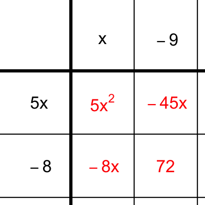

Or, you can FOIL...

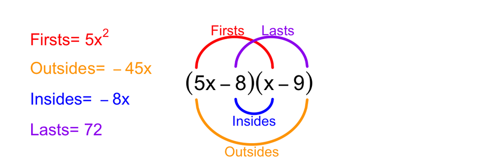

Either way, you should first get
$${5}x^{2}-{45}x-{8}x+{72}$$

And, after combining like terms, you should get
$${5}x^{2}-{53}x+{72}$$

Thus, $a=5$ and $b=-53$ and $c=72$. This question specifically asked for the value of $b$, so the answer is $-53$.

Consider the following product of linear binomials:

$$(-x+{6})({-2}x+{7})$$

When the expression is expanded and like terms are combined, an equivalent expression can be expressed in standard form:

$$ax^2+bx+c$$

where $a$, $b$, and $c$ are integers.

- What is the value of $b$?

You could use the box method.

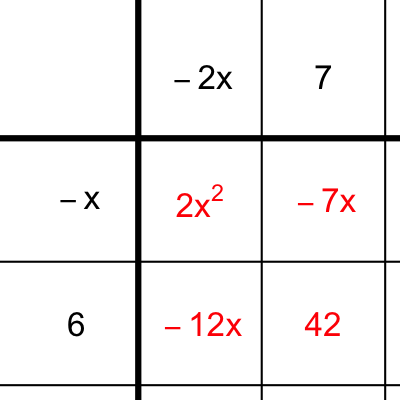

Or, you can FOIL...

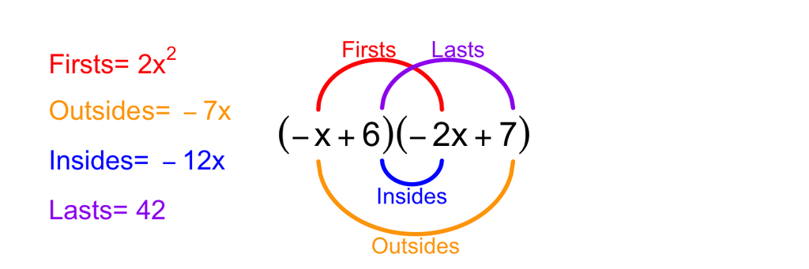

Either way, you should first get
$${2}x^{2}-{7}x-{12}x+{42}$$

And, after combining like terms, you should get
$${2}x^{2}-{19}x+{42}$$

Thus, $a=2$ and $b=-19$ and $c=42$. This question specifically asked for the value of $b$, so the answer is $-19$.

Consider the following product of linear binomials:

$$({-8}x-{5})({2}x+{1})$$

When the expression is expanded and like terms are combined, an equivalent expression can be expressed in standard form:

$$ax^2+bx+c$$

where $a$, $b$, and $c$ are integers.

- What is the value of $b$?

You could use the box method.

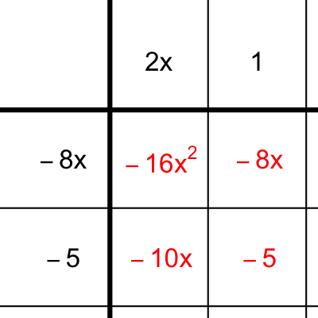

Or, you can FOIL...

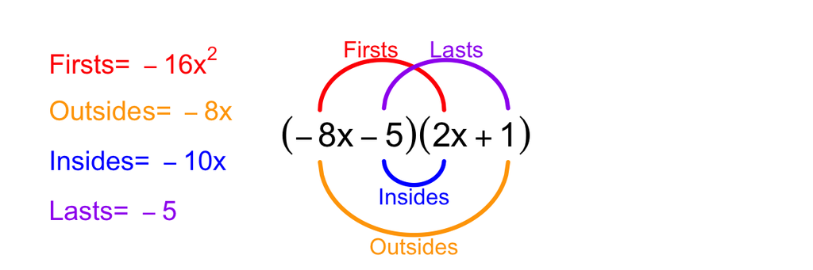

Either way, you should first get
$${-16}x^{2}-{8}x-{10}x-{5}$$

And, after combining like terms, you should get
$${-16}x^{2}-{18}x-{5}$$

Thus, $a=-16$ and $b=-18$ and $c=-5$. This question specifically asked for the value of $b$, so the answer is $-18$.

Consider the following product of linear binomials:

$$({-7}x+{5})({5}x+{3})$$

When the expression is expanded and like terms are combined, an equivalent expression can be expressed in standard form:

$$ax^2+bx+c$$

where $a$, $b$, and $c$ are integers.

- What is the value of $b$?

You could use the box method.

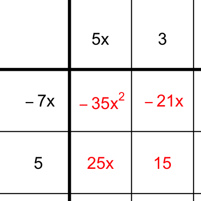

Or, you can FOIL...

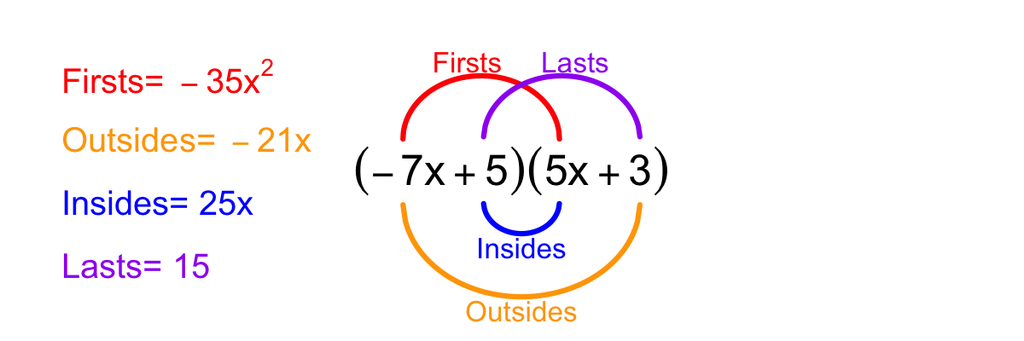

Either way, you should first get
$${-35}x^{2}-{21}x+{25}x+{15}$$

And, after combining like terms, you should get
$${-35}x^{2}+{4}x+{15}$$

Thus, $a=-35$ and $b=4$ and $c=15$. This question specifically asked for the value of $b$, so the answer is $4$.

Consider the following product of linear binomials:

$$(-x+{5})({8}x+{6})$$

When the expression is expanded and like terms are combined, an equivalent expression can be expressed in standard form:

$$ax^2+bx+c$$

where $a$, $b$, and $c$ are integers.

- What is the value of $b$?

You could use the box method.

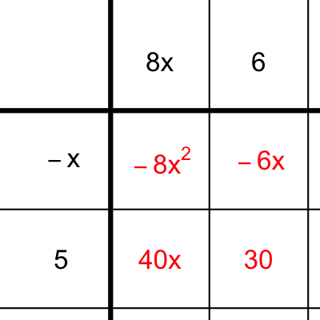

Or, you can FOIL...

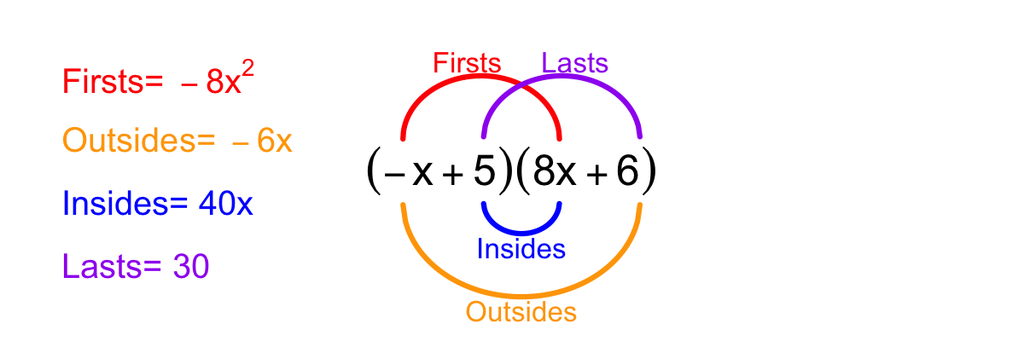

Either way, you should first get
$${-8}x^{2}-{6}x+{40}x+{30}$$

And, after combining like terms, you should get
$${-8}x^{2}+{34}x+{30}$$

Thus, $a=-8$ and $b=34$ and $c=30$. This question specifically asked for the value of $b$, so the answer is $34$.

Consider the quadratic expression shown in standard form:

$${5}x^{2}+{38}x+{21}$$

In factored form, the expression can be represented as the product of two factors. What are those factors?

$x-{10}$${5}x-{10}$$x-{9}$${5}x-{9}$$x-{8}$${5}x-{8}$$x-{7}$${5}x-{7}$$x-{6}$${5}x-{6}$$x-{5}$${5}x-{5}$$x-{4}$${5}x-{4}$$x-{3}$${5}x-{3}$$x-{2}$${5}x-{2}$$x-{1}$${5}x-{1}$$x+{1}$${5}x+{1}$$x+{2}$${5}x+{2}$$x+{3}$${5}x+{3}$$x+{4}$${5}x+{4}$$x+{5}$${5}x+{5}$$x+{6}$${5}x+{6}$$x+{7}$${5}x+{7}$$x+{8}$${5}x+{8}$$x+{9}$${5}x+{9}$$x+{10}$${5}x+{10}$

Rewrite the given quadratic expression:

$${5}x^{2}+{38}x+{21}$$

Set up a box with what you know... Notice that the leading (quadratic) coefficient, $a=5$, is prime. This allows us to be more confident in how this expression factors.

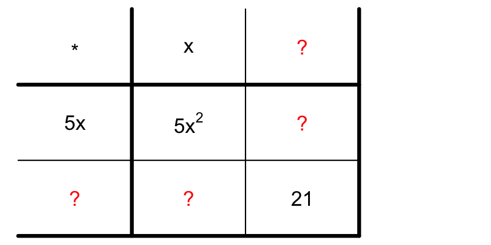

You can get this by guessing and checking. To make a smart guess, find a pair of integers that multiply to get $21$, and use those...

Eventually, because $(3)\cdot(7)=21$, you will guess the following factored form:

$$({5}x+{3})\cdot(x+{7})$$

And you will check it with a box to see that it works.

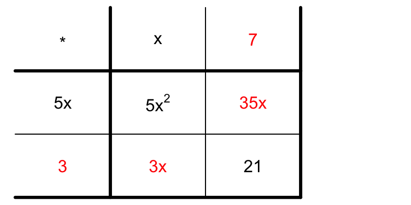

$${5}x^{2}+{35}x+{3}x+{21}$$

Combine like terms.

$${5}x^{2}+{38}x+{21}$$

So it worked! (Because it matches the given standard-form expression.) Thus, in factored form, the expression is:

$$({5}x+{3})\cdot(x+{7})$$

And, the two factors are $({5}x+{3})$ and $(x+{7})$

Consider the quadratic expression shown in standard form:

$${3}x^{2}-{10}x+{3}$$

In factored form, the expression can be represented as the product of two factors. What are those factors?

$x-{10}$${3}x-{10}$$x-{9}$${3}x-{9}$$x-{8}$${3}x-{8}$$x-{7}$${3}x-{7}$$x-{6}$${3}x-{6}$$x-{5}$${3}x-{5}$$x-{4}$${3}x-{4}$$x-{3}$${3}x-{3}$$x-{2}$${3}x-{2}$$x-{1}$${3}x-{1}$$x+{1}$${3}x+{1}$$x+{2}$${3}x+{2}$$x+{3}$${3}x+{3}$$x+{4}$${3}x+{4}$$x+{5}$${3}x+{5}$$x+{6}$${3}x+{6}$$x+{7}$${3}x+{7}$$x+{8}$${3}x+{8}$$x+{9}$${3}x+{9}$$x+{10}$${3}x+{10}$

Rewrite the given quadratic expression:

$${3}x^{2}-{10}x+{3}$$

Set up a box with what you know... Notice that the leading (quadratic) coefficient, $a=3$, is prime. This allows us to be more confident in how this expression factors.

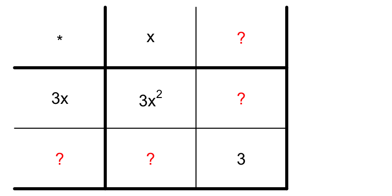

You can get this by guessing and checking. To make a smart guess, find a pair of integers that multiply to get $3$, and use those...

Eventually, because $(-1)\cdot(-3)=3$, you will guess the following factored form:

$$({3}x-{1})\cdot(x-{3})$$

And you will check it with a box to see that it works.

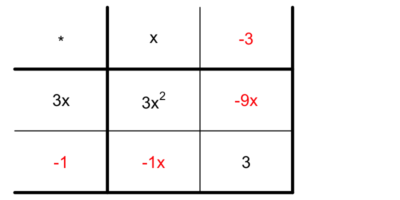

$${3}x^{2}-{9}x-x+{3}$$

Combine like terms.

$${3}x^{2}-{10}x+{3}$$

So it worked! (Because it matches the given standard-form expression.) Thus, in factored form, the expression is:

$$({3}x-{1})\cdot(x-{3})$$

And, the two factors are $({3}x-{1})$ and $(x-{3})$

Consider the quadratic expression shown in standard form:

$${3}x^{2}+{26}x-{40}$$

In factored form, the expression can be represented as the product of two factors. What are those factors?

$x-{10}$${3}x-{10}$$x-{9}$${3}x-{9}$$x-{8}$${3}x-{8}$$x-{7}$${3}x-{7}$$x-{6}$${3}x-{6}$$x-{5}$${3}x-{5}$$x-{4}$${3}x-{4}$$x-{3}$${3}x-{3}$$x-{2}$${3}x-{2}$$x-{1}$${3}x-{1}$$x+{1}$${3}x+{1}$$x+{2}$${3}x+{2}$$x+{3}$${3}x+{3}$$x+{4}$${3}x+{4}$$x+{5}$${3}x+{5}$$x+{6}$${3}x+{6}$$x+{7}$${3}x+{7}$$x+{8}$${3}x+{8}$$x+{9}$${3}x+{9}$$x+{10}$${3}x+{10}$

Rewrite the given quadratic expression:

$${3}x^{2}+{26}x-{40}$$

Set up a box with what you know... Notice that the leading (quadratic) coefficient, $a=3$, is prime. This allows us to be more confident in how this expression factors.

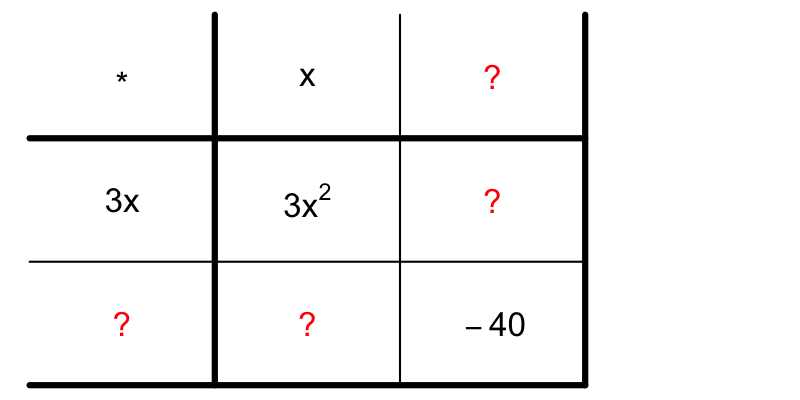

You can get this by guessing and checking. To make a smart guess, find a pair of integers that multiply to get $-40$, and use those...

Eventually, because $(-4)\cdot(10)=-40$, you will guess the following factored form:

$$({3}x-{4})\cdot(x+{10})$$

And you will check it with a box to see that it works.

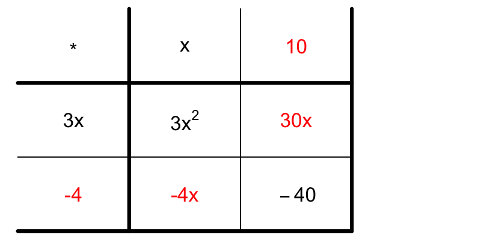

$${3}x^{2}+{30}x-{4}x-{40}$$

Combine like terms.

$${3}x^{2}+{26}x-{40}$$

So it worked! (Because it matches the given standard-form expression.) Thus, in factored form, the expression is:

$$({3}x-{4})\cdot(x+{10})$$

And, the two factors are $({3}x-{4})$ and $(x+{10})$

Consider the quadratic expression shown in standard form:

$${5}x^{2}+{52}x+{20}$$

In factored form, the expression can be represented as the product of two factors. What are those factors?

$x-{10}$${5}x-{10}$$x-{9}$${5}x-{9}$$x-{8}$${5}x-{8}$$x-{7}$${5}x-{7}$$x-{6}$${5}x-{6}$$x-{5}$${5}x-{5}$$x-{4}$${5}x-{4}$$x-{3}$${5}x-{3}$$x-{2}$${5}x-{2}$$x-{1}$${5}x-{1}$$x+{1}$${5}x+{1}$$x+{2}$${5}x+{2}$$x+{3}$${5}x+{3}$$x+{4}$${5}x+{4}$$x+{5}$${5}x+{5}$$x+{6}$${5}x+{6}$$x+{7}$${5}x+{7}$$x+{8}$${5}x+{8}$$x+{9}$${5}x+{9}$$x+{10}$${5}x+{10}$

Rewrite the given quadratic expression:

$${5}x^{2}+{52}x+{20}$$

Set up a box with what you know... Notice that the leading (quadratic) coefficient, $a=5$, is prime. This allows us to be more confident in how this expression factors.

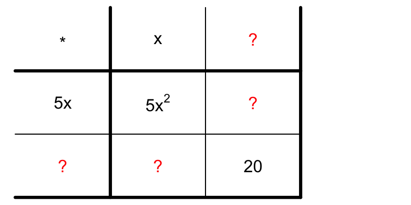

You can get this by guessing and checking. To make a smart guess, find a pair of integers that multiply to get $20$, and use those...

Eventually, because $(2)\cdot(10)=20$, you will guess the following factored form:

$$({5}x+{2})\cdot(x+{10})$$

And you will check it with a box to see that it works.

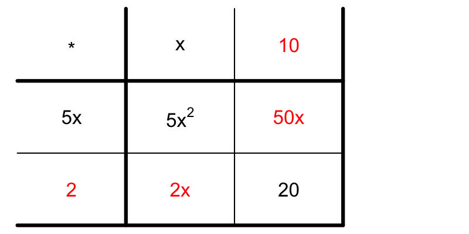

$${5}x^{2}+{50}x+{2}x+{20}$$

Combine like terms.

$${5}x^{2}+{52}x+{20}$$

So it worked! (Because it matches the given standard-form expression.) Thus, in factored form, the expression is:

$$({5}x+{2})\cdot(x+{10})$$

And, the two factors are $({5}x+{2})$ and $(x+{10})$

Consider the quadratic expression shown in standard form:

$${7}x^{2}-{22}x-{24}$$

In factored form, the expression can be represented as the product of two factors. What are those factors?

$x-{10}$${7}x-{10}$$x-{9}$${7}x-{9}$$x-{8}$${7}x-{8}$$x-{7}$${7}x-{7}$$x-{6}$${7}x-{6}$$x-{5}$${7}x-{5}$$x-{4}$${7}x-{4}$$x-{3}$${7}x-{3}$$x-{2}$${7}x-{2}$$x-{1}$${7}x-{1}$$x+{1}$${7}x+{1}$$x+{2}$${7}x+{2}$$x+{3}$${7}x+{3}$$x+{4}$${7}x+{4}$$x+{5}$${7}x+{5}$$x+{6}$${7}x+{6}$$x+{7}$${7}x+{7}$$x+{8}$${7}x+{8}$$x+{9}$${7}x+{9}$$x+{10}$${7}x+{10}$

Rewrite the given quadratic expression:

$${7}x^{2}-{22}x-{24}$$

Set up a box with what you know... Notice that the leading (quadratic) coefficient, $a=7$, is prime. This allows us to be more confident in how this expression factors.

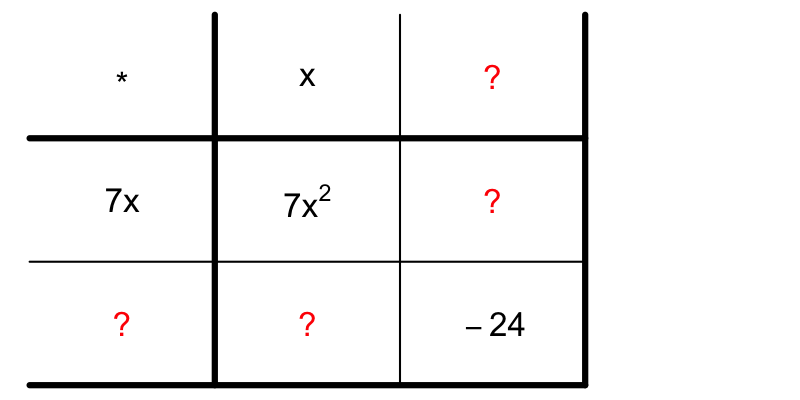

You can get this by guessing and checking. To make a smart guess, find a pair of integers that multiply to get $-24$, and use those...

Eventually, because $(6)\cdot(-4)=-24$, you will guess the following factored form:

$$({7}x+{6})\cdot(x-{4})$$

And you will check it with a box to see that it works.

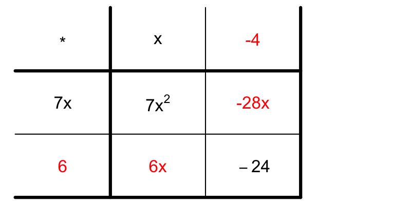

$${7}x^{2}-{28}x+{6}x-{24}$$

Combine like terms.

$${7}x^{2}-{22}x-{24}$$

So it worked! (Because it matches the given standard-form expression.) Thus, in factored form, the expression is:

$$({7}x+{6})\cdot(x-{4})$$

And, the two factors are $({7}x+{6})$ and $(x-{4})$

Find all solutions to the equation below:

$$(x+{9})^2~=~36$$

-20-19-18-17-16-15-14-13-12-11-10-9-8-7-6-5-4-3-2-101234567891011121314151617181920

Notice, because the squaring function is NOT one-to-one, when we "undo" it on both sides of an equation, we need to consider multiple possibilities.

In this case, you should know that, when squared, both $-6$ and $6$ produce $36$.

$$(x+{9})^2~=~36$$

$$x+{9}~=~\pm6$$

$$x~=~-9\pm6$$

So the two solutions are $x=-3$ and $x=-15$.

Find all solutions to the equation below:

$$(x-{5})^2~=~16$$

-20-19-18-17-16-15-14-13-12-11-10-9-8-7-6-5-4-3-2-101234567891011121314151617181920

Notice, because the squaring function is NOT one-to-one, when we "undo" it on both sides of an equation, we need to consider multiple possibilities.

In this case, you should know that, when squared, both $-4$ and $4$ produce $16$.

$$(x-{5})^2~=~16$$

$$x-{5}~=~\pm4$$

$$x~=~5\pm4$$

So the two solutions are $x=9$ and $x=1$.

Find all solutions to the equation below:

$$(x+{5})^2~=~16$$

-20-19-18-17-16-15-14-13-12-11-10-9-8-7-6-5-4-3-2-101234567891011121314151617181920

Notice, because the squaring function is NOT one-to-one, when we "undo" it on both sides of an equation, we need to consider multiple possibilities.

In this case, you should know that, when squared, both $-4$ and $4$ produce $16$.

$$(x+{5})^2~=~16$$

$$x+{5}~=~\pm4$$

$$x~=~-5\pm4$$

So the two solutions are $x=-1$ and $x=-9$.

Find all solutions to the equation below:

$$(x-{5})^2~=~64$$

-20-19-18-17-16-15-14-13-12-11-10-9-8-7-6-5-4-3-2-101234567891011121314151617181920

Notice, because the squaring function is NOT one-to-one, when we "undo" it on both sides of an equation, we need to consider multiple possibilities.

In this case, you should know that, when squared, both $-8$ and $8$ produce $64$.

$$(x-{5})^2~=~64$$

$$x-{5}~=~\pm8$$

$$x~=~5\pm8$$

So the two solutions are $x=13$ and $x=-3$.

Find all solutions to the equation below:

$$(x-{8})^2~=~25$$

-20-19-18-17-16-15-14-13-12-11-10-9-8-7-6-5-4-3-2-101234567891011121314151617181920

Notice, because the squaring function is NOT one-to-one, when we "undo" it on both sides of an equation, we need to consider multiple possibilities.

In this case, you should know that, when squared, both $-5$ and $5$ produce $25$.

$$(x-{8})^2~=~25$$

$$x-{8}~=~\pm5$$

$$x~=~8\pm5$$

So the two solutions are $x=13$ and $x=3$.

**Find the remainder** when $6x³-41x²+27x+14$ is divided by $x-6$.

Fill out the polynomial long division shown below to divide $6x³-41x²+27x+14$ by $x-6$.

|  |  |  | 6x² | -5x | -3 |  |  |
| --- | --- | --- | --- | --- | --- | --- | --- |
| x | -6 | 6x³ | -41x² | +27x | +14 |  |  |
|  | $-($ | 6x³ | -36x² | $)$ |  |  |  |
|  |  |  | -5x² | +27x |  |  |  |
|  |  | $-($ | -5x² | +30x | $)$ |  |  |
|  |  |  |  | -3x | +14 |  |  |
|  |  |  | $-($ | -3x | +18 | $)$ |  |
|  |  |  |  |  | -4 |  |  |

Thus, the following identity holds true for all values of $x$ (but $x\ne 6$):

$$\frac{6x^3-41x^2+27x+14}{x-6}~=~6x^2-5x-3+\frac{-4}{x-6}$$

And the remainder is $-4$.

**Find the remainder** when $9x³+28x²-29x+6$ is divided by $x+4$.

Fill out the polynomial long division shown below to divide $9x³+28x²-29x+6$ by $x+4$.

|  |  |  | 9x² | -8x | +3 |  |  |
| --- | --- | --- | --- | --- | --- | --- | --- |
| x | +4 | 9x³ | +28x² | -29x | +6 |  |  |
|  | $-($ | 9x³ | +36x² | $)$ |  |  |  |
|  |  |  | -8x² | -29x |  |  |  |
|  |  | $-($ | -8x² | -32x | $)$ |  |  |
|  |  |  |  | 3x | +6 |  |  |
|  |  |  | $-($ | 3x | +12 | $)$ |  |
|  |  |  |  |  | -6 |  |  |

Thus, the following identity holds true for all values of $x$ (but $x\ne -4$):

$$\frac{9x^3+28x^2-29x+6}{x+4}~=~9x^2-8x+3+\frac{-6}{x+4}$$

And the remainder is $-6$.

**Find the remainder** when $3x³-17x²-62x+54$ is divided by $x-8$.

Fill out the polynomial long division shown below to divide $3x³-17x²-62x+54$ by $x-8$.

|  |  |  | 3x² | +7x | -6 |  |  |
| --- | --- | --- | --- | --- | --- | --- | --- |
| x | -8 | 3x³ | -17x² | -62x | +54 |  |  |
|  | $-($ | 3x³ | -24x² | $)$ |  |  |  |
|  |  |  | 7x² | -62x |  |  |  |
|  |  | $-($ | 7x² | -56x | $)$ |  |  |
|  |  |  |  | -6x | +54 |  |  |
|  |  |  | $-($ | -6x | +48 | $)$ |  |
|  |  |  |  |  | 6 |  |  |

Thus, the following identity holds true for all values of $x$ (but $x\ne 8$):

$$\frac{3x^3-17x^2-62x+54}{x-8}~=~3x^2+7x-6+\frac{6}{x-8}$$

And the remainder is $6$.

**Find the remainder** when $6x³-20x²-13x-9$ is divided by $x-4$.

Fill out the polynomial long division shown below to divide $6x³-20x²-13x-9$ by $x-4$.

|  |  |  | 6x² | +4x | +3 |  |  |
| --- | --- | --- | --- | --- | --- | --- | --- |
| x | -4 | 6x³ | -20x² | -13x | -9 |  |  |
|  | $-($ | 6x³ | -24x² | $)$ |  |  |  |
|  |  |  | 4x² | -13x |  |  |  |
|  |  | $-($ | 4x² | -16x | $)$ |  |  |
|  |  |  |  | 3x | -9 |  |  |
|  |  |  | $-($ | 3x | -12 | $)$ |  |
|  |  |  |  |  | 3 |  |  |

Thus, the following identity holds true for all values of $x$ (but $x\ne 4$):

$$\frac{6x^3-20x^2-13x-9}{x-4}~=~6x^2+4x+3+\frac{3}{x-4}$$

And the remainder is $3$.

**Find the remainder** when $2x³+13x²+14x-26$ is divided by $x+4$.

Fill out the polynomial long division shown below to divide $2x³+13x²+14x-26$ by $x+4$.

|  |  |  | 2x² | +5x | -6 |  |  |
| --- | --- | --- | --- | --- | --- | --- | --- |
| x | +4 | 2x³ | +13x² | +14x | -26 |  |  |
|  | $-($ | 2x³ | +8x² | $)$ |  |  |  |
|  |  |  | 5x² | +14x |  |  |  |
|  |  | $-($ | 5x² | +20x | $)$ |  |  |
|  |  |  |  | -6x | -26 |  |  |
|  |  |  | $-($ | -6x | -24 | $)$ |  |
|  |  |  |  |  | -2 |  |  |

Thus, the following identity holds true for all values of $x$ (but $x\ne -4$):

$$\frac{2x^3+13x^2+14x-26}{x+4}~=~2x^2+5x-6+\frac{-2}{x+4}$$

And the remainder is $-2$.

Consider the shifted [square-root function](https://en.wikipedia.org/wiki/Square_root) graphed below:

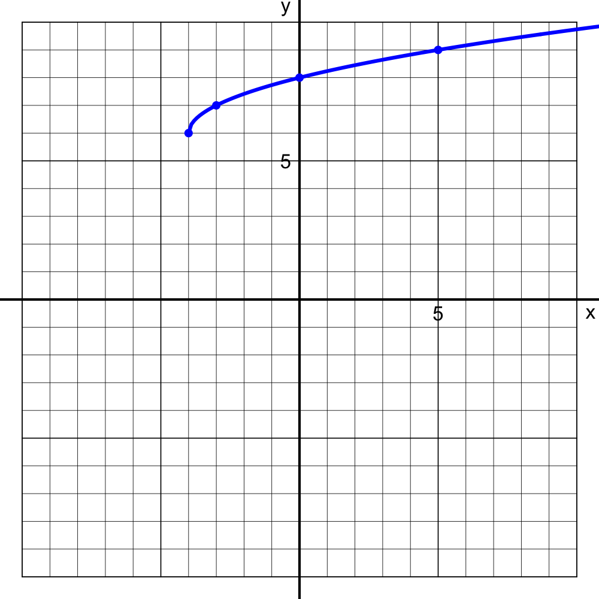

Which equation represents the plotted curve?

$y=\sqrt{x-4}-6$$y=\sqrt{x-4}+6$$y=\sqrt{x-6}-4$$y=\sqrt{x-6}+4$$y=\sqrt{x+4}-6$$y=\sqrt{x+4}+6$$y=\sqrt{x+6}-4$$y=\sqrt{x+6}+4$

The parent function, $y=\sqrt{x}$, has been shifted $4$ units left and $6$ units up.

The correct answer is
$$y=\sqrt{x+4}+6$$

Notice the horizontal translation is counterintuitive. The horizontal coordinate transformation is the INVERSE of the argument expression, whereas the vertical coordinate transformation is simply the outer operations.

$$(a,b)~\to~(a-4,b+6)$$

where $(a,b)$ is a solution to the parent equation $\sqrt{a}=b$. For example, $\sqrt{0}=0$ or $\sqrt{1}=1$ or $\sqrt{4}=2$ or $\sqrt{9}=3$... Thus from curve $y=\sqrt{x}$ to curve $y=\sqrt{x+4}+6$, we have the following coordinate transformations:

$$(0,0) \to (-4,6)$$
$$(1,1) \to (-3,7)$$
$$(4,2) \to (0,8)$$
$$(9,3) \to (5,9)$$

Consider the shifted [square-root function](https://en.wikipedia.org/wiki/Square_root) graphed below:

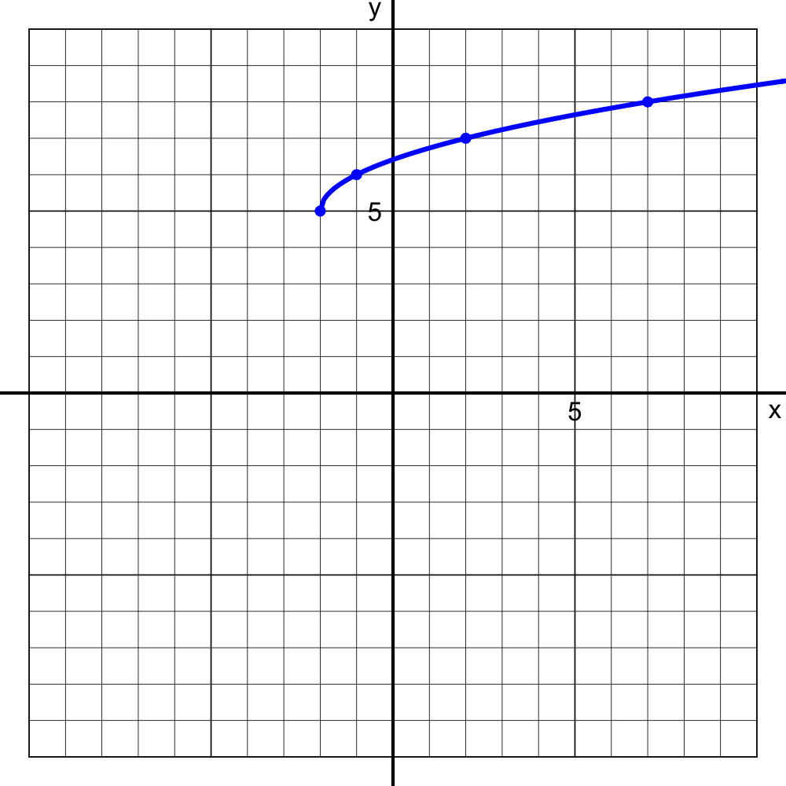

Which equation represents the plotted curve?

$y=\sqrt{x-2}-5$$y=\sqrt{x-2}+5$$y=\sqrt{x-5}-2$$y=\sqrt{x-5}+2$$y=\sqrt{x+2}-5$$y=\sqrt{x+2}+5$$y=\sqrt{x+5}-2$$y=\sqrt{x+5}+2$

The parent function, $y=\sqrt{x}$, has been shifted $2$ units left and $5$ units up.

The correct answer is
$$y=\sqrt{x+2}+5$$

Notice the horizontal translation is counterintuitive. The horizontal coordinate transformation is the INVERSE of the argument expression, whereas the vertical coordinate transformation is simply the outer operations.

$$(a,b)~\to~(a-2,b+5)$$

where $(a,b)$ is a solution to the parent equation $\sqrt{a}=b$. For example, $\sqrt{0}=0$ or $\sqrt{1}=1$ or $\sqrt{4}=2$ or $\sqrt{9}=3$... Thus from curve $y=\sqrt{x}$ to curve $y=\sqrt{x+2}+5$, we have the following coordinate transformations:

$$(0,0) \to (-2,5)$$
$$(1,1) \to (-1,6)$$
$$(4,2) \to (2,7)$$
$$(9,3) \to (7,8)$$

Consider the shifted [square-root function](https://en.wikipedia.org/wiki/Square_root) graphed below:

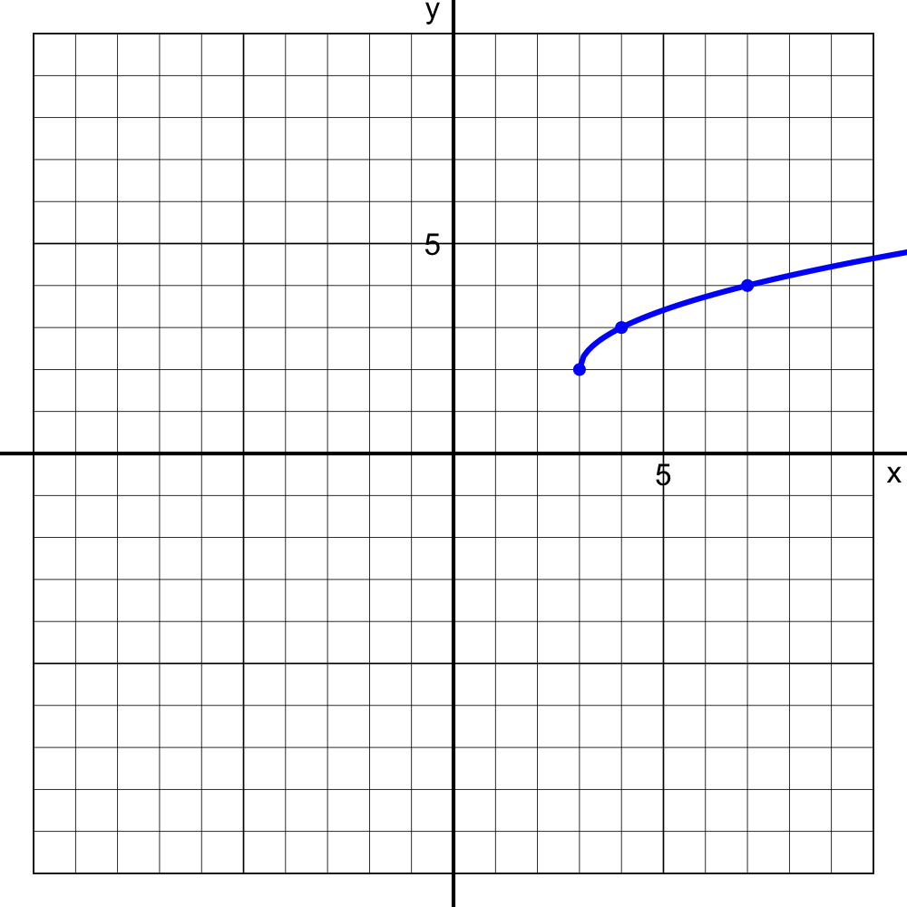

Which equation represents the plotted curve?

$y=\sqrt{x-2}-3$$y=\sqrt{x-2}+3$$y=\sqrt{x-3}-2$$y=\sqrt{x-3}+2$$y=\sqrt{x+2}-3$$y=\sqrt{x+2}+3$$y=\sqrt{x+3}-2$$y=\sqrt{x+3}+2$

The parent function, $y=\sqrt{x}$, has been shifted $3$ units right and $2$ units up.

The correct answer is
$$y=\sqrt{x-3}+2$$

Notice the horizontal translation is counterintuitive. The horizontal coordinate transformation is the INVERSE of the argument expression, whereas the vertical coordinate transformation is simply the outer operations.

$$(a,b)~\to~(a+3,b+2)$$

where $(a,b)$ is a solution to the parent equation $\sqrt{a}=b$. For example, $\sqrt{0}=0$ or $\sqrt{1}=1$ or $\sqrt{4}=2$ or $\sqrt{9}=3$... Thus from curve $y=\sqrt{x}$ to curve $y=\sqrt{x-3}+2$, we have the following coordinate transformations:

$$(0,0) \to (3,2)$$
$$(1,1) \to (4,3)$$
$$(4,2) \to (7,4)$$
$$(9,3) \to (12,5)$$

Consider the shifted [square-root function](https://en.wikipedia.org/wiki/Square_root) graphed below:

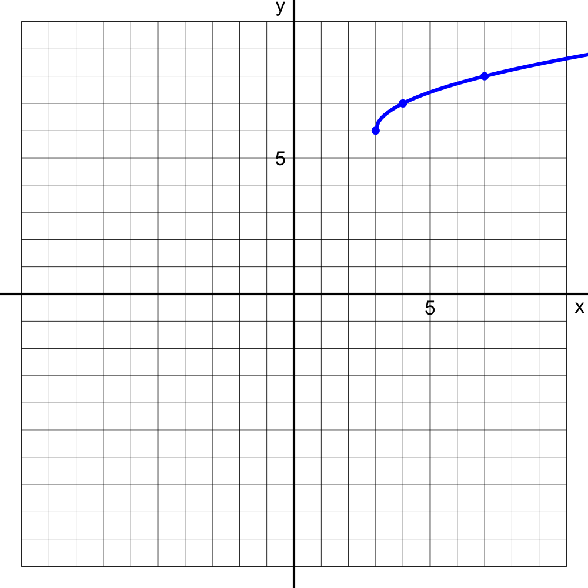

Which equation represents the plotted curve?

$y=\sqrt{x-3}-6$$y=\sqrt{x-3}+6$$y=\sqrt{x-6}-3$$y=\sqrt{x-6}+3$$y=\sqrt{x+3}-6$$y=\sqrt{x+3}+6$$y=\sqrt{x+6}-3$$y=\sqrt{x+6}+3$

The parent function, $y=\sqrt{x}$, has been shifted $3$ units right and $6$ units up.

The correct answer is
$$y=\sqrt{x-3}+6$$

Notice the horizontal translation is counterintuitive. The horizontal coordinate transformation is the INVERSE of the argument expression, whereas the vertical coordinate transformation is simply the outer operations.

$$(a,b)~\to~(a+3,b+6)$$

where $(a,b)$ is a solution to the parent equation $\sqrt{a}=b$. For example, $\sqrt{0}=0$ or $\sqrt{1}=1$ or $\sqrt{4}=2$ or $\sqrt{9}=3$... Thus from curve $y=\sqrt{x}$ to curve $y=\sqrt{x-3}+6$, we have the following coordinate transformations:

$$(0,0) \to (3,6)$$
$$(1,1) \to (4,7)$$
$$(4,2) \to (7,8)$$
$$(9,3) \to (12,9)$$

Consider the shifted [square-root function](https://en.wikipedia.org/wiki/Square_root) graphed below:

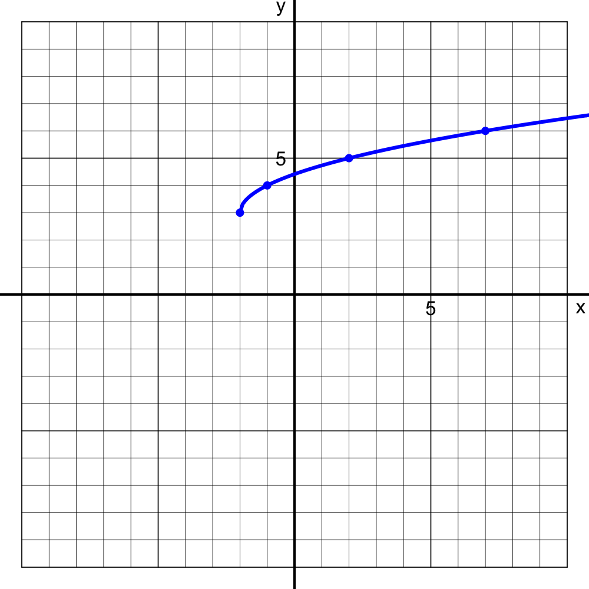

Which equation represents the plotted curve?

$y=\sqrt{x-2}-3$$y=\sqrt{x-2}+3$$y=\sqrt{x-3}-2$$y=\sqrt{x-3}+2$$y=\sqrt{x+2}-3$$y=\sqrt{x+2}+3$$y=\sqrt{x+3}-2$$y=\sqrt{x+3}+2$

The parent function, $y=\sqrt{x}$, has been shifted $2$ units left and $3$ units up.

The correct answer is
$$y=\sqrt{x+2}+3$$

Notice the horizontal translation is counterintuitive. The horizontal coordinate transformation is the INVERSE of the argument expression, whereas the vertical coordinate transformation is simply the outer operations.

$$(a,b)~\to~(a-2,b+3)$$

where $(a,b)$ is a solution to the parent equation $\sqrt{a}=b$. For example, $\sqrt{0}=0$ or $\sqrt{1}=1$ or $\sqrt{4}=2$ or $\sqrt{9}=3$... Thus from curve $y=\sqrt{x}$ to curve $y=\sqrt{x+2}+3$, we have the following coordinate transformations:

$$(0,0) \to (-2,3)$$
$$(1,1) \to (-1,4)$$
$$(4,2) \to (2,5)$$
$$(9,3) \to (7,6)$$

A rectangle's width is 2 meters shorter than its height. The area is 274 square meters. In meters, what is the height? (*Answers should be accurate within $\pm 0.1$ meters*)

Let $x$ represent the height. The width is $x-{2}$. The area of a rectangle equals the product of height times width.

$$274~=~x\cdot (x-{2})$$

Distribute the multiplication of $x$ to the terms in parentheses.

$$274~=~x^{2}-{2}x$$

Subtract 274 from both sides.

$$0~=~x^{2}-{2}x-{274}$$

Now the right side of the equation is in standard form. We can identify $a$, $b$, and $c$ in order to use the quadratic formula.

$$a=1$$
$$b=-2$$
$$c=-274$$

Remember the formula.

$$x~=~\frac{-b\pm
\sqrt{b^2-4ac}}{2a}$$

Plug in the coefficients.

$$x~=~\frac{-(-2)\pm
\sqrt{(-2)^2-4(1)(-274)}}{2(1)}$$

Simplify.

$$x~=~\frac{2\pm
\sqrt{{4}+{1096}}}{2}$$

Simplify more.

$$x~=~\frac{2\pm
\sqrt{1100}}{2}$$

Simplify more.

$$x~=~\frac{2\pm
10\sqrt{11}}{2}$$

Simplify more.
$$x~=~1\pm
5\sqrt{11}$$

This (or, honestly, one of the earlier, less simplified expressions) can be put into a calculator to get the two possible values for $x$ as decimal approximations. We are only interested in the positive solution.

$$x=17.583124$$

A rectangle's height is 12 meters longer than its width. The area is 76 square meters. In meters, what is the height? (*Answers should be accurate within $\pm 0.1$ meters*)

Let $x$ represent the height. The width is $x-{12}$. The area of a rectangle equals the product of height times width.

$$76~=~x\cdot (x-{12})$$

Distribute the multiplication of $x$ to the terms in parentheses.

$$76~=~x^{2}-{12}x$$

Subtract 76 from both sides.

$$0~=~x^{2}-{12}x-{76}$$

Now the right side of the equation is in standard form. We can identify $a$, $b$, and $c$ in order to use the quadratic formula.

$$a=1$$
$$b=-12$$
$$c=-76$$

Remember the formula.

$$x~=~\frac{-b\pm
\sqrt{b^2-4ac}}{2a}$$

Plug in the coefficients.

$$x~=~\frac{-(-12)\pm
\sqrt{(-12)^2-4(1)(-76)}}{2(1)}$$

Simplify.

$$x~=~\frac{12\pm
\sqrt{{144}+{304}}}{2}$$

Simplify more.

$$x~=~\frac{12\pm
\sqrt{448}}{2}$$

Simplify more.

$$x~=~\frac{12\pm
8\sqrt{7}}{2}$$

Simplify more.
$$x~=~6\pm
4\sqrt{7}$$

This (or, honestly, one of the earlier, less simplified expressions) can be put into a calculator to get the two possible values for $x$ as decimal approximations. We are only interested in the positive solution.

$$x=16.5830052$$

A rectangle's width is 2 meters longer than its height. The area is 149 square meters. In meters, what is the height? (*Answers should be accurate within $\pm 0.1$ meters*)

Let $x$ represent the height. The width is $x+{2}$. The area of a rectangle equals the product of height times width.

$$149~=~x\cdot (x+{2})$$

Distribute the multiplication of $x$ to the terms in parentheses.

$$149~=~x^{2}+{2}x$$

Subtract 149 from both sides.

$$0~=~x^{2}+{2}x-{149}$$

Now the right side of the equation is in standard form. We can identify $a$, $b$, and $c$ in order to use the quadratic formula.

$$a=1$$
$$b=2$$
$$c=-149$$

Remember the formula.

$$x~=~\frac{-b\pm
\sqrt{b^2-4ac}}{2a}$$

Plug in the coefficients.

$$x~=~\frac{-(2)\pm
\sqrt{(2)^2-4(1)(-149)}}{2(1)}$$

Simplify.

$$x~=~\frac{-2\pm
\sqrt{{4}+{596}}}{2}$$

Simplify more.

$$x~=~\frac{-2\pm
\sqrt{600}}{2}$$

Simplify more.

$$x~=~\frac{-2\pm
10\sqrt{6}}{2}$$

Simplify more.
$$x~=~-1\pm
5\sqrt{6}$$

This (or, honestly, one of the earlier, less simplified expressions) can be put into a calculator to get the two possible values for $x$ as decimal approximations. We are only interested in the positive solution.

$$x=11.2474487$$

A rectangle's width is 5 meters shorter than its height. The area is 68 square meters. In meters, what is the height? (*Answers should be accurate within $\pm 0.1$ meters*)

Let $x$ represent the height. The width is $x-{5}$. The area of a rectangle equals the product of height times width.

$$68~=~x\cdot (x-{5})$$

Distribute the multiplication of $x$ to the terms in parentheses.

$$68~=~x^{2}-{5}x$$

Subtract 68 from both sides.

$$0~=~x^{2}-{5}x-{68}$$

Now the right side of the equation is in standard form. We can identify $a$, $b$, and $c$ in order to use the quadratic formula.

$$a=1$$
$$b=-5$$
$$c=-68$$

Remember the formula.

$$x~=~\frac{-b\pm
\sqrt{b^2-4ac}}{2a}$$

Plug in the coefficients.

$$x~=~\frac{-(-5)\pm
\sqrt{(-5)^2-4(1)(-68)}}{2(1)}$$

Simplify.

$$x~=~\frac{5\pm
\sqrt{{25}+{272}}}{2}$$

Simplify more.

$$x~=~\frac{5\pm
\sqrt{297}}{2}$$

Simplify more.

$$x~=~\frac{5\pm
3\sqrt{33}}{2}$$

This (or, honestly, one of the earlier, less simplified expressions) can be put into a calculator to get the two possible values for $x$ as decimal approximations. We are only interested in the positive solution.

$$x=11.116844$$

A rectangle's width is 8 meters longer than its height. The area is 245 square meters. In meters, what is the height? (*Answers should be accurate within $\pm 0.1$ meters*)

Let $x$ represent the height. The width is $x+{8}$. The area of a rectangle equals the product of height times width.

$$245~=~x\cdot (x+{8})$$

Distribute the multiplication of $x$ to the terms in parentheses.

$$245~=~x^{2}+{8}x$$

Subtract 245 from both sides.

$$0~=~x^{2}+{8}x-{245}$$

Now the right side of the equation is in standard form. We can identify $a$, $b$, and $c$ in order to use the quadratic formula.

$$a=1$$
$$b=8$$
$$c=-245$$

Remember the formula.

$$x~=~\frac{-b\pm
\sqrt{b^2-4ac}}{2a}$$

Plug in the coefficients.

$$x~=~\frac{-(8)\pm
\sqrt{(8)^2-4(1)(-245)}}{2(1)}$$

Simplify.

$$x~=~\frac{-8\pm
\sqrt{{64}+{980}}}{2}$$

Simplify more.

$$x~=~\frac{-8\pm
\sqrt{1044}}{2}$$

Simplify more.

$$x~=~\frac{-8\pm
6\sqrt{29}}{2}$$

Simplify more.
$$x~=~-4\pm
3\sqrt{29}$$

This (or, honestly, one of the earlier, less simplified expressions) can be put into a calculator to get the two possible values for $x$ as decimal approximations. We are only interested in the positive solution.

$$x=12.1554944$$

Consider the quadratic **equation** with a standard-form quadratic expression on the left side and zero on the right side.

$$x^{2}+{7}x+{12}~=~0$$

Find all solutions.

$x=-12$$x=-11$$x=-10$$x=-9$$x=-8$$x=-7$$x=-6$$x=-5$$x=-4$$x=-3$$x=-2$$x=-1$$x=0$$x=1$$x=2$$x=3$$x=4$$x=5$$x=6$$x=7$$x=8$$x=9$$x=10$$x=11$$x=12$

[Factor the left-side expression](https://chadworley.github.io/algtwo2026/u03/1031/outhtml/factor_quadratic.html).

$$(x+{4}) (x+{3})=0$$

The [zero-product property](https://en.wikipedia.org/wiki/Zero-product_property) tells us that if a product equals 0, then at least one of the factors of the product equals 0. In this case, we know the product of $(x+{4})$ and $(x+{3})$ equals zero. This means to satisfy the equation either $x+{4}$ equals zero or $x+{3}$ equals zero. Solve each of these using addition or subtraction.

- First solution:
  $$x+{4}=0$$
  $$x=-4$$
- Second solution:
  $$x+{3}=0$$
  $$x=-3$$

Thus, the two solutions are $x=-4$ and $x=-3$.

Consider the quadratic **equation** with a standard-form quadratic expression on the left side and zero on the right side.

$$x^{2}-{4}x-{45}~=~0$$

Find all solutions.

$x=-12$$x=-11$$x=-10$$x=-9$$x=-8$$x=-7$$x=-6$$x=-5$$x=-4$$x=-3$$x=-2$$x=-1$$x=0$$x=1$$x=2$$x=3$$x=4$$x=5$$x=6$$x=7$$x=8$$x=9$$x=10$$x=11$$x=12$

[Factor the left-side expression](https://chadworley.github.io/algtwo2026/u03/1031/outhtml/factor_quadratic.html).

$$(x+{5}) (x-{9})=0$$

The [zero-product property](https://en.wikipedia.org/wiki/Zero-product_property) tells us that if a product equals 0, then at least one of the factors of the product equals 0. In this case, we know the product of $(x+{5})$ and $(x-{9})$ equals zero. This means to satisfy the equation either $x+{5}$ equals zero or $x-{9}$ equals zero. Solve each of these using addition or subtraction.

- First solution:
  $$x+{5}=0$$
  $$x=-5$$
- Second solution:
  $$x-{9}=0$$
  $$x=9$$

Thus, the two solutions are $x=-5$ and $x=9$.

Consider the quadratic **equation** with a standard-form quadratic expression on the left side and zero on the right side.

$$x^{2}-{6}x+{8}~=~0$$

Find all solutions.

$x=-12$$x=-11$$x=-10$$x=-9$$x=-8$$x=-7$$x=-6$$x=-5$$x=-4$$x=-3$$x=-2$$x=-1$$x=0$$x=1$$x=2$$x=3$$x=4$$x=5$$x=6$$x=7$$x=8$$x=9$$x=10$$x=11$$x=12$

[Factor the left-side expression](https://chadworley.github.io/algtwo2026/u03/1031/outhtml/factor_quadratic.html).

$$(x-{2}) (x-{4})=0$$

The [zero-product property](https://en.wikipedia.org/wiki/Zero-product_property) tells us that if a product equals 0, then at least one of the factors of the product equals 0. In this case, we know the product of $(x-{2})$ and $(x-{4})$ equals zero. This means to satisfy the equation either $x-{2}$ equals zero or $x-{4}$ equals zero. Solve each of these using addition or subtraction.

- First solution:
  $$x-{2}=0$$
  $$x=2$$
- Second solution:
  $$x-{4}=0$$
  $$x=4$$

Thus, the two solutions are $x=2$ and $x=4$.

Consider the quadratic **equation** with a standard-form quadratic expression on the left side and zero on the right side.

$$x^{2}-{15}x+{36}~=~0$$

Find all solutions.

$x=-12$$x=-11$$x=-10$$x=-9$$x=-8$$x=-7$$x=-6$$x=-5$$x=-4$$x=-3$$x=-2$$x=-1$$x=0$$x=1$$x=2$$x=3$$x=4$$x=5$$x=6$$x=7$$x=8$$x=9$$x=10$$x=11$$x=12$

[Factor the left-side expression](https://chadworley.github.io/algtwo2026/u03/1031/outhtml/factor_quadratic.html).

$$(x-{12}) (x-{3})=0$$

The [zero-product property](https://en.wikipedia.org/wiki/Zero-product_property) tells us that if a product equals 0, then at least one of the factors of the product equals 0. In this case, we know the product of $(x-{12})$ and $(x-{3})$ equals zero. This means to satisfy the equation either $x-{12}$ equals zero or $x-{3}$ equals zero. Solve each of these using addition or subtraction.

- First solution:
  $$x-{12}=0$$
  $$x=12$$
- Second solution:
  $$x-{3}=0$$
  $$x=3$$

Thus, the two solutions are $x=12$ and $x=3$.

Consider the quadratic **equation** with a standard-form quadratic expression on the left side and zero on the right side.

$$x^{2}-{5}x-{14}~=~0$$

Find all solutions.

$x=-12$$x=-11$$x=-10$$x=-9$$x=-8$$x=-7$$x=-6$$x=-5$$x=-4$$x=-3$$x=-2$$x=-1$$x=0$$x=1$$x=2$$x=3$$x=4$$x=5$$x=6$$x=7$$x=8$$x=9$$x=10$$x=11$$x=12$

[Factor the left-side expression](https://chadworley.github.io/algtwo2026/u03/1031/outhtml/factor_quadratic.html).

$$(x+{2}) (x-{7})=0$$

The [zero-product property](https://en.wikipedia.org/wiki/Zero-product_property) tells us that if a product equals 0, then at least one of the factors of the product equals 0. In this case, we know the product of $(x+{2})$ and $(x-{7})$ equals zero. This means to satisfy the equation either $x+{2}$ equals zero or $x-{7}$ equals zero. Solve each of these using addition or subtraction.

- First solution:
  $$x+{2}=0$$
  $$x=-2$$
- Second solution:
  $$x-{7}=0$$
  $$x=7$$

Thus, the two solutions are $x=-2$ and $x=7$.

Simplify the following expression so that the denominator is a positive real integer. Also reduce the fraction if possible.

$$\frac{4+6i}{7+3i}$$

Your answer will have the form $\frac{r+qi}{n}$.

*If your answer is $\frac{4-10i}{3}$, type your answer as `(4-10i)/3` without any spaces.*

Multiply the numerator and denominator by the complex conjugate of the denominator.

$$\frac{(4+6i)(7-3i)}{(7+3i)(7-3i)}$$

"FOIL" the numerator and "FOIL" the denominator.

$$\frac{28-12i+42i-18i^2}{49-21i+21i-9i^2}$$

Remember, $i^2=-1$.

$$\frac{28-12i+42i+18}{49-21i+21i+9}$$

Combine like terms.

$$\frac{46+30i}{58}$$

If all terms have a common factor, reduce the fraction. The greatest common factor of 46 and 30 and 58 is the number 2.

$$\frac{23+15i}{29}$$

So, your answer is typed exactly like `(23+15i)/29` without any spaces.

Simplify the following expression so that the denominator is a positive real integer. Also reduce the fraction if possible.

$$\frac{6+2i}{3+5i}$$

Your answer will have the form $\frac{r+qi}{n}$.

*If your answer is $\frac{4-10i}{3}$, type your answer as `(4-10i)/3` without any spaces.*

Multiply the numerator and denominator by the complex conjugate of the denominator.

$$\frac{(6+2i)(3-5i)}{(3+5i)(3-5i)}$$

"FOIL" the numerator and "FOIL" the denominator.

$$\frac{18-30i+6i-10i^2}{9-15i+15i-25i^2}$$

Remember, $i^2=-1$.

$$\frac{18-30i+6i+10}{9-15i+15i+25}$$

Combine like terms.

$$\frac{28-24i}{34}$$

If all terms have a common factor, reduce the fraction. The greatest common factor of 28 and 24 and 34 is the number 2.

$$\frac{14-12i}{17}$$

So, your answer is typed exactly like `(14-12i)/17` without any spaces.

Simplify the following expression so that the denominator is a positive real integer. Also reduce the fraction if possible.

$$\frac{6+9i}{3+2i}$$

Your answer will have the form $\frac{r+qi}{n}$.

*If your answer is $\frac{4-10i}{3}$, type your answer as `(4-10i)/3` without any spaces.*

Multiply the numerator and denominator by the complex conjugate of the denominator.

$$\frac{(6+9i)(3-2i)}{(3+2i)(3-2i)}$$

"FOIL" the numerator and "FOIL" the denominator.

$$\frac{18-12i+27i-18i^2}{9-6i+6i-4i^2}$$

Remember, $i^2=-1$.

$$\frac{18-12i+27i+18}{9-6i+6i+4}$$

Combine like terms.

$$\frac{36+15i}{13}$$

If all terms have a common factor, reduce the fraction. The greatest common factor of 36 and 15 and 13 is the number 1.

$$\frac{36+15i}{13}$$

So, your answer is typed exactly like `(36+15i)/13` without any spaces.

Simplify the following expression so that the denominator is a positive real integer. Also reduce the fraction if possible.

$$\frac{-5-9i}{2-4i}$$

Your answer will have the form $\frac{r+qi}{n}$.

*If your answer is $\frac{4-10i}{3}$, type your answer as `(4-10i)/3` without any spaces.*

Multiply the numerator and denominator by the complex conjugate of the denominator.

$$\frac{(-5-9i)(2+4i)}{(2-4i)(2+4i)}$$

"FOIL" the numerator and "FOIL" the denominator.

$$\frac{-10-20i-18i-36i^2}{4+8i-8i-16i^2}$$

Remember, $i^2=-1$.

$$\frac{-10-20i-18i+36}{4+8i-8i+16}$$

Combine like terms.

$$\frac{26-38i}{20}$$

If all terms have a common factor, reduce the fraction. The greatest common factor of 26 and 38 and 20 is the number 2.

$$\frac{13-19i}{10}$$

So, your answer is typed exactly like `(13-19i)/10` without any spaces.

Simplify the following expression so that the denominator is a positive real integer. Also reduce the fraction if possible.

$$\frac{-3-4i}{7-2i}$$

Your answer will have the form $\frac{r+qi}{n}$.

*If your answer is $\frac{4-10i}{3}$, type your answer as `(4-10i)/3` without any spaces.*

Multiply the numerator and denominator by the complex conjugate of the denominator.

$$\frac{(-3-4i)(7+2i)}{(7-2i)(7+2i)}$$

"FOIL" the numerator and "FOIL" the denominator.

$$\frac{-21-6i-28i-8i^2}{49+14i-14i-4i^2}$$

Remember, $i^2=-1$.

$$\frac{-21-6i-28i+8}{49+14i-14i+4}$$

Combine like terms.

$$\frac{-13-34i}{53}$$

If all terms have a common factor, reduce the fraction. The greatest common factor of 13 and 34 and 53 is the number 1.

$$\frac{-13-34i}{53}$$

So, your answer is typed exactly like `(-13-34i)/53` without any spaces.